# LendingClub

Jake Bowmer

23 February 2016

This is the R Markdown version of a brief analysis done on the publicly available lending club loan dataset.

```r
#library imports and data import:
library(stringr)
library(dplyr)
library(lubridate)
library(randomForest)
library(reshape2)
library(ggplot2)
data = read.csv("/Users/Jake/Projects/LendingClub/LoanStats3a.csv", header=TRUE, stringsAsFactors=FALSE, skip=1)

head(data)
```

```
##        id member_id loan_amnt funded_amnt funded_amnt_inv       term
## 1 1077501   1296599      5000        5000            4975  36 months
## 2 1077430   1314167      2500        2500            2500  60 months
## 3 1077175   1313524      2400        2400            2400  36 months
## 4 1076863   1277178     10000       10000           10000  36 months
## 5 1075358   1311748      3000        3000            3000  60 months
## 6 1075269   1311441      5000        5000            5000  36 months
##   int_rate installment grade sub_grade                emp_title emp_length
## 1   10.65%      162.87     B        B2                           10+ years
## 2   15.27%       59.83     C        C4                    Ryder   < 1 year
## 3   15.96%       84.33     C        C5                           10+ years
## 4   13.49%      339.31     C        C1      AIR RESOURCES BOARD  10+ years
## 5   12.69%       67.79     B        B5 University Medical Group     1 year
## 6    7.90%      156.46     A        A4     Veolia Transportaton    3 years
##   home_ownership annual_inc verification_status  issue_d loan_status
```

[output cut: 111 more lines]

```r
dim(data)
```

```
## [1] 42538    74
```

```r
names(data)
```

```
##  [1] "id"                          "member_id"
##  [3] "loan_amnt"                   "funded_amnt"
##  [5] "funded_amnt_inv"             "term"
##  [7] "int_rate"                    "installment"
##  [9] "grade"                       "sub_grade"
## [11] "emp_title"                   "emp_length"
## [13] "home_ownership"              "annual_inc"
## [15] "verification_status"         "issue_d"
## [17] "loan_status"                 "pymnt_plan"
## [19] "url"                         "desc"
## [21] "purpose"                     "title"
## [23] "zip_code"                    "addr_state"
## [25] "dti"                         "delinq_2yrs"
## [27] "earliest_cr_line"            "inq_last_6mths"
## [29] "mths_since_last_delinq"      "mths_since_last_record"
```

[output cut: 22 more lines]

```r
summary(data)
```

```
##       id              member_id         loan_amnt      funded_amnt
##  Length:42538       Min.   :  70473   Min.   :  500   Min.   :  500
##  Class :character   1st Qu.: 638480   1st Qu.: 5200   1st Qu.: 5000
##  Mode  :character   Median : 824178   Median : 9700   Median : 9600
##                     Mean   : 825703   Mean   :11090   Mean   :10822
##                     3rd Qu.:1033946   3rd Qu.:15000   3rd Qu.:15000
##                     Max.   :1314167   Max.   :35000   Max.   :35000
##                     NA's   :3         NA's   :3       NA's   :3
##  funded_amnt_inv     term             int_rate          installment
##  Min.   :    0   Length:42538       Length:42538       Min.   :  15.67
##  1st Qu.: 4950   Class :character   Class :character   1st Qu.: 165.52
##  Median : 8500   Mode  :character   Mode  :character   Median : 277.69
##  Mean   :10140                                         Mean   : 322.62
##  3rd Qu.:14000                                         3rd Qu.: 428.18
##  Max.   :35000                                         Max.   :1305.19
##  NA's   :3                                             NA's   :3
##     grade            sub_grade          emp_title
##  Length:42538       Length:42538       Length:42538
##  Class :character   Class :character   Class :character
##  Mode  :character   Mode  :character   Mode  :character
##
##
##
##
##   emp_length        home_ownership       annual_inc
##  Length:42538       Length:42538       Min.   :   1896
##  Class :character   Class :character   1st Qu.:  40000
##  Mode  :character   Mode  :character   Median :  59000
##                                        Mean   :  69137
##                                        3rd Qu.:  82500
##                                        Max.   :6000000
##                                        NA's   :7
##  verification_status   issue_d          loan_status
##  Length:42538        Length:42538       Length:42538
##  Class :character    Class :character   Class :character
##  Mode  :character    Mode  :character   Mode  :character
##
##
##
##
```

[output cut: 113 more lines]

```
##  Mode:logical   Mode:logical   Mode:logical   Mode:logical
##  NA's:42538     NA's:42538     NA's:42538     NA's:42538
##
##
##
##
##
##   inq_fi        total_cu_tl    inq_last_12m
##  Mode:logical   Mode:logical   Mode:logical
##  NA's:42538     NA's:42538     NA's:42538
##
##
##
##
##
```

From the above, we can see that there are a number of columns consisting almost entirely of NA values. In addition, the description column, while potentially useful from a text mining point of view, is outside the scope of this example. We remove these columns.

```r
data = subset(data, select = -desc)
data = select(data, id:last_credit_pull_d)
```

A simple model predicting whether a loan turns “bad” or not is a binary classification problem. We need to adjust our dataset to highlight the loans that have gone bad.

```r
#create a binary indicator of whether a loan is considered bad or good.
bad = c("Late (31-120 days)", "Default", "Charged Off")
data$bad_loans = ifelse(data$loan_status %in% bad, 1, ifelse(data$loan_status=="", NA, 0))
data$bad_loans = factor(data$bad_loans)
```

# Analysis

This results in 5634 bad loans from a total of 42538. We can use this column to investigates potential explanatory variables. We briefly look at, for examples sake, loan amount, term, interest rate and grade and its effect on bad loans. We first look at loan amount and how bad loans vary with the loan amount.

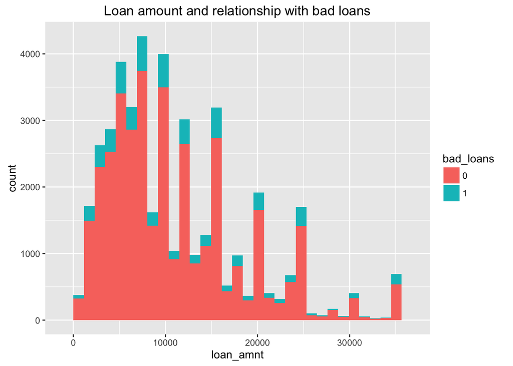

```r
ggplot(data = data, aes(x = loan_amnt, fill = bad_loans)) + geom_histogram() +
  ggtitle ("Loan amount and relationship with bad loans")
```

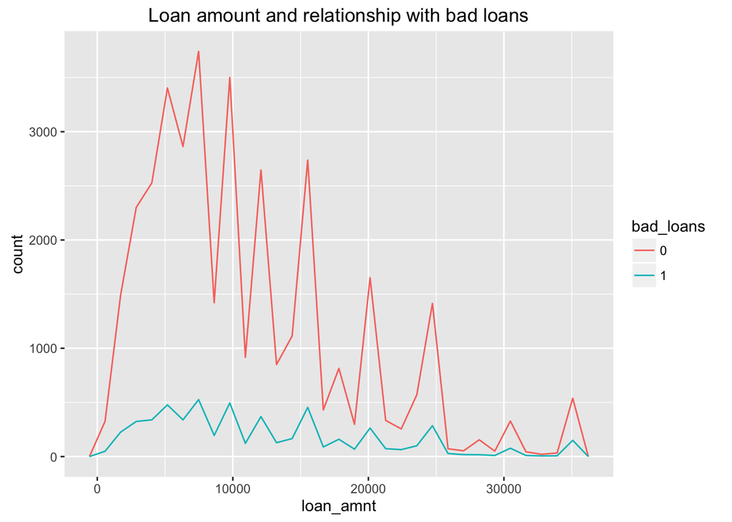

```r
ggplot(data = data, aes(x = loan_amnt, color = bad_loans)) + geom_freqpoly() +
  ggtitle("Loan amount and relationship with bad loans")
```

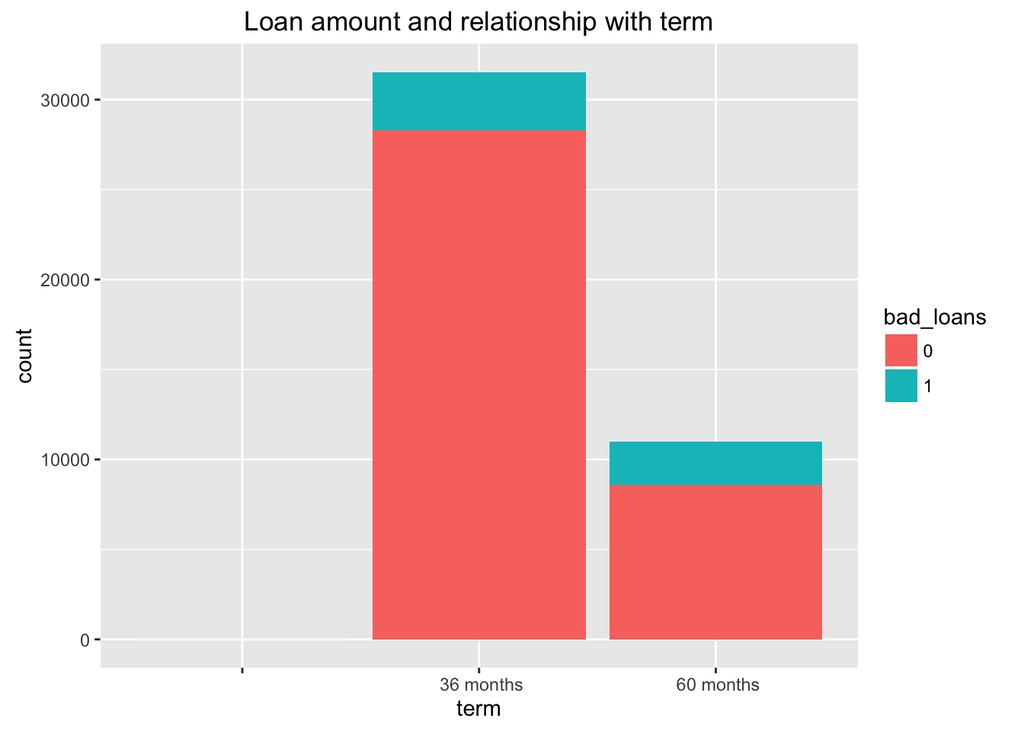

```r
ggplot(data = data, aes(x = term,  fill =  bad_loans)) + geom_bar() +
  ggtitle("Loan amount and relationship with term")
```

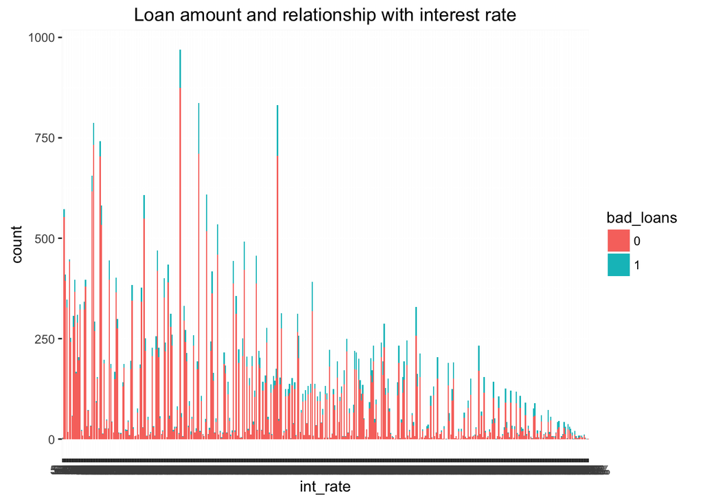

```r
ggplot(data = data, aes(x = int_rate, fill = bad_loans)) + geom_bar() +
  ggtitle("Loan amount and relationship with interest rate") #This chart would be improved with binning into categories.
```

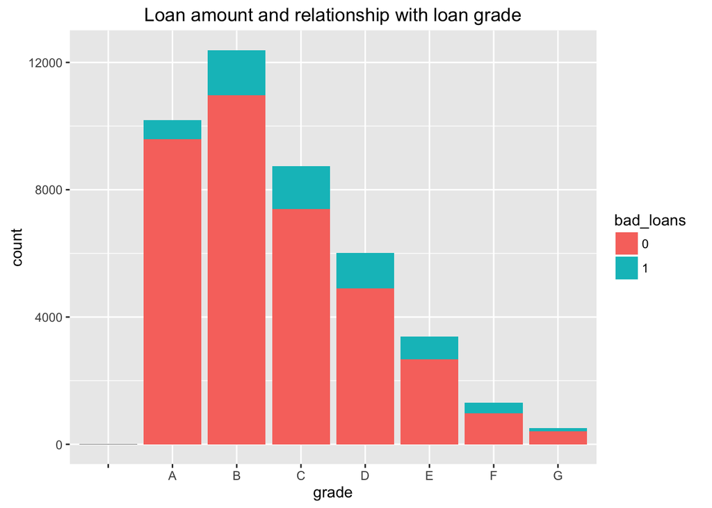

```r
ggplot(data = data, aes(x = grade, fill = bad_loans)) + geom_bar() +
  ggtitle("Loan amount and relationship with loan grade") #Potentially the most interesting chart of the ones presented.
```

Finally, we create a simple model and look at its performance on a test set.

```r
data$renter = ifelse(data$home_ownership == 'RENT', 1, 0)
data_rf = select(data, loan_amnt, term, grade, renter, annual_inc, bad_loans)
summary(data_rf)
```

```
##    loan_amnt         term              grade               renter
##  Min.   :  500   Length:42538       Length:42538       Min.   :0.0000
##  1st Qu.: 5200   Class :character   Class :character   1st Qu.:0.0000
##  Median : 9700   Mode  :character   Mode  :character   Median :0.0000
##  Mean   :11090                                         Mean   :0.4744
##  3rd Qu.:15000                                         3rd Qu.:1.0000
##  Max.   :35000                                         Max.   :1.0000
##  NA's   :3
##    annual_inc      bad_loans
##  Min.   :   1896   0   :36901
##  1st Qu.:  40000   1   : 5634
##  Median :  59000   NA's:    3
##  Mean   :  69137
##  3rd Qu.:  82500
##  Max.   :6000000
##  NA's   :7
```

```r
data_rf$grade = factor(data_rf$grade)
data_rf$term = factor(data_rf$term)
data_rf = na.omit(data_rf)

library(caret)
split = createDataPartition(data_rf$bad_loans, p=0.75, list = FALSE)
training = data_rf[split,]
test = data_rf[-split,]

#train model on training set
rf = randomForest(as.factor(bad_loans) ~ loan_amnt + term + grade + renter + annual_inc,
                  type="classification", data=training, importance=TRUE, na.action=na.omit)
#Predict on test set
data_rf_predict = factor(predict(rf, newdata = test))

#We can see that our model is not yet very useful:
table(data_rf_predict, test$bad_loans)
```

```
##
## data_rf_predict    0    1
##               0 9221 1406
##               1    3    2
```

We see that the simple model is not particularly useful. The addition of the fico score makes the problem solvable, but lending club has scrubbed fico data from its public datasets as the addition of fico data causes privacy issues.